# Lab 4 - Homework 29 Oct 2020

Nikita Grabher-Meyer

10/29/2020

## Setup: set working directory, load packages and data set

```r
setwd("/Users/nikitagrabher-meyer/Desktop/PHD/Econometrics/Labs/Lab 4")

library(data.table)
library(ggplot2)
require(stargazer)
load("affairs.RData")
dt.affairs <- data.table(data)
rm(data)
```

## Summary statistics

```r
stargazer(dt.affairs, type = "text")
```

```
##
## ============================================================
## Statistic  N    Mean    St. Dev. Min Pctl(25) Pctl(75)  Max
## ------------------------------------------------------------
## id        601 1,059.722 914.905   4    528     1,453   9,029
## male      601   0.476    0.500    0     0        1       1
## age       601  32.488    9.289   18     27       37     57
## yrsmarr   601   8.178    5.571    0     4        15     15
## kids      601   0.715    0.452    0     0        1       1
## relig     601   3.116    1.168    1     2        4       5
## educ      601  16.166    2.403    9     14       18     20
## occup     601   4.195    1.819    1     3        6       7
## ratemarr  601   3.932    1.103    1     3        5       5
## naffairs  601   1.456    3.299    0     0        0      12
## affair    601   0.250    0.433    0     0        0       1
## vryhap    601   0.386    0.487    0     0        1       1
## hapavg    601   0.323    0.468    0     0        1       1
## avgmarr   601   0.155    0.362    0     0        0       1
## unhap     601   0.110    0.313    0     0        0       1
## vryrel    601   0.116    0.321    0     0        0       1
## smerel    601   0.316    0.465    0     0        1       1
## slghtrel  601   0.215    0.411    0     0        0       1
## notrel    601   0.273    0.446    0     0        1       1
## ------------------------------------------------------------
```

## Hypothesis

### Two-sided hypothesis test

*Hypotheses regarding the likelihood and number of extra-marital affairs* *H0 : μ (non−religious) − μ (religious)=0* *H1 : μ (non−religious) − μ (religious)!=0*

Create an indicator variable for “religious”

```r
dt.affairs[, religious:= relig>3]
```

Check how many people are in each group

```r
dt.affairs[, .N, by = religious]
```

```
##    religious   N
## 1:     FALSE 341
## 2:      TRUE 260
```

Run t.test on the likelihood of extra-marital affairs

```r
dt.affairs[, t.test(affair ~ religious)]
```

```
##
##  Welch Two Sample t-test
##
## data:  affair by religious
## t = 3.7191, df = 594.76, p-value = 0.0002189
## alternative hypothesis: true difference in means is not equal to 0
## 95 percent confidence interval:
##  0.06043572 0.19568880
## sample estimates:
## mean in group FALSE  mean in group TRUE
##           0.3049853           0.1769231
```

The p-value is below 0.05, therefore we reject HO that there is no difference in the mean probability of having an affair between the religious and non-religious group

Run t.test on the number of extra-marital affairs

```r
dt.affairs[, t.test(naffairs ~ religious)]
```

```
##
##  Welch Two Sample t-test
##
## data:  naffairs by religious
## t = 4.0676, df = 593.3, p-value = 5.393e-05
## alternative hypothesis: true difference in means is not equal to 0
## 95 percent confidence interval:
##  0.5382493 1.5432981
## sample estimates:
## mean in group FALSE  mean in group TRUE
##           1.9061584           0.8653846
```

The p-value is below 0.05, therefore we reject HO that there is no difference in the average number of affairs between the religious and non-religious group

### One-sided hypothesis test

*Hypotheses regarding the likelihood and number of extra-marital affairs* *H0 : μ (non−religious) − μ (religious)<=0* *H1 : μ (non−religious) − μ (religious)>0*

Run t.test on the likelihood of extra-marital affairs

```r
dt.affairs[, t.test(affair ~ religious, alternative = c("greater"))]
```

```
##
##  Welch Two Sample t-test
##
## data:  affair by religious
## t = 3.7191, df = 594.76, p-value = 0.0001094
## alternative hypothesis: true difference in means is greater than 0
## 95 percent confidence interval:
##  0.07133542        Inf
## sample estimates:
## mean in group FALSE  mean in group TRUE
##           0.3049853           0.1769231
```

Run t.test on the number of extra-marital affairs

```r
dt.affairs[, t.test(naffairs ~ religious, alternative = c("greater"))]
```

```
##
##  Welch Two Sample t-test
##
## data:  naffairs by religious
## t = 4.0676, df = 593.3, p-value = 2.696e-05
## alternative hypothesis: true difference in means is greater than 0
## 95 percent confidence interval:
##  0.6192441       Inf
## sample estimates:
## mean in group FALSE  mean in group TRUE
##           1.9061584           0.8653846
```

## Multiple Regression

### Case: Direct marketing

*Predict the amount spent*

Load the data

```r
dt.mktg <- data.table(read.csv("DirectMarketing.csv"))
dt.mktg <- setnames(dt.mktg, tolower(names(dt.mktg)))
```

Get to know the data

```r
nrow(dt.mktg)
```

```
## [1] 1000
```

```r
colnames(dt.mktg)
```

```
##  [1] "age"         "gender"      "ownhome"     "married"     "location"
##  [6] "salary"      "children"    "history"     "catalogs"    "amountspent"
```

```r
head(dt.mktg)
```

```
##       age gender ownhome married location salary children history catalogs
## 1:    Old Female     Own  Single      Far  47500        0    High        6
## 2: Middle   Male    Rent  Single    Close  63600        0    High        6
## 3:  Young Female    Rent  Single    Close  13500        0     Low       18
## 4: Middle   Male     Own Married    Close  85600        1    High       18
## 5: Middle Female     Own  Single    Close  68400        0    High       12
## 6:  Young   Male     Own Married    Close  30400        0     Low        6
##    amountspent
## 1:         755
## 2:        1318
## 3:         296
## 4:        2436
## 5:        1304
## 6:         495
```

```r
summary(dt.mktg)
```

```
##      age               gender            ownhome            married
##  Length:1000        Length:1000        Length:1000        Length:1000
##  Class :character   Class :character   Class :character   Class :character
##  Mode  :character   Mode  :character   Mode  :character   Mode  :character
##
##
##
##    location             salary          children       history
##  Length:1000        Min.   : 10100   Min.   :0.000   Length:1000
##  Class :character   1st Qu.: 29975   1st Qu.:0.000   Class :character
##  Mode  :character   Median : 53700   Median :1.000   Mode  :character
##                     Mean   : 56104   Mean   :0.934
##                     3rd Qu.: 77025   3rd Qu.:2.000
##                     Max.   :168800   Max.   :3.000
##     catalogs      amountspent
##  Min.   : 6.00   Min.   :  38.0
##  1st Qu.: 6.00   1st Qu.: 488.2
##  Median :12.00   Median : 962.0
##  Mean   :14.68   Mean   :1216.8
##  3rd Qu.:18.00   3rd Qu.:1688.5
##  Max.   :24.00   Max.   :6217.0
```

```r
stargazer(dt.mktg, type = "text")
```

```
##
## ========================================================================
## Statistic     N      Mean     St. Dev.   Min   Pctl(25) Pctl(75)   Max
## ------------------------------------------------------------------------
## salary      1,000 56,103.900 30,616.310 10,100  29,975   77,025  168,800
## children    1,000   0.934      1.051      0       0        2        3
## catalogs    1,000   14.682     6.623      6       6        18      24
## amountspent 1,000 1,216.770   961.069     38    488.2   1,688.5   6,217
## ------------------------------------------------------------------------
```

Explore the data graphically

1. Age

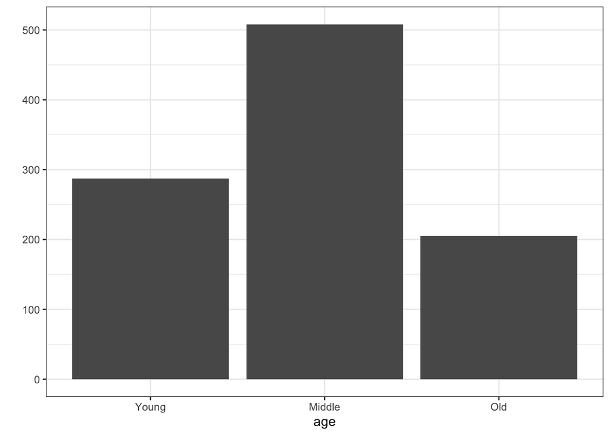

```r
qplot( data = dt.mktg
, x = age
, geom = "bar") + theme_bw() + xlim("Young","Middle","Old")
```

2. Gender

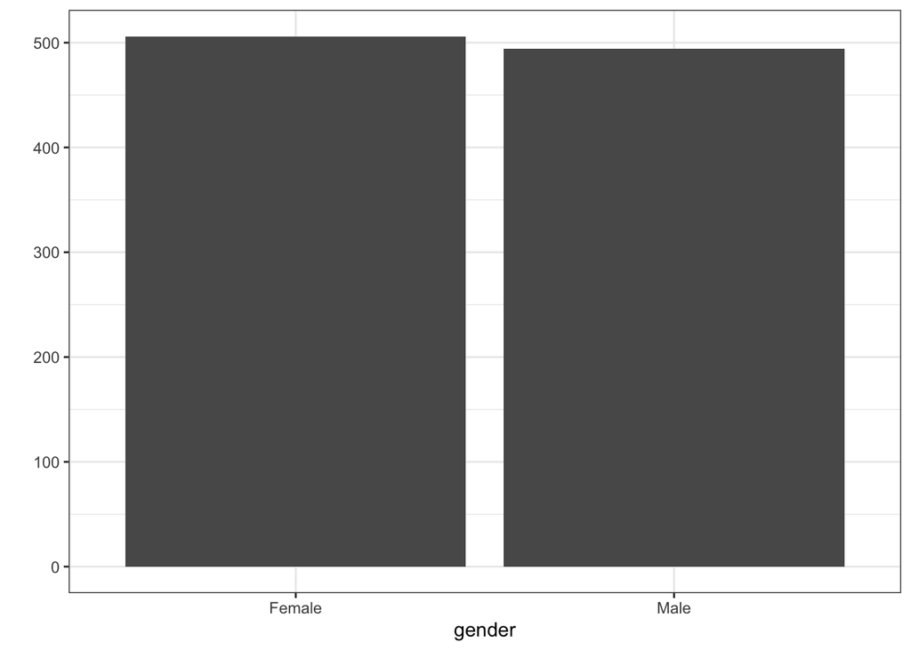

```r
qplot( data = dt.mktg
, x = gender
, geom = "bar") + theme_bw()
```

3. Own a home

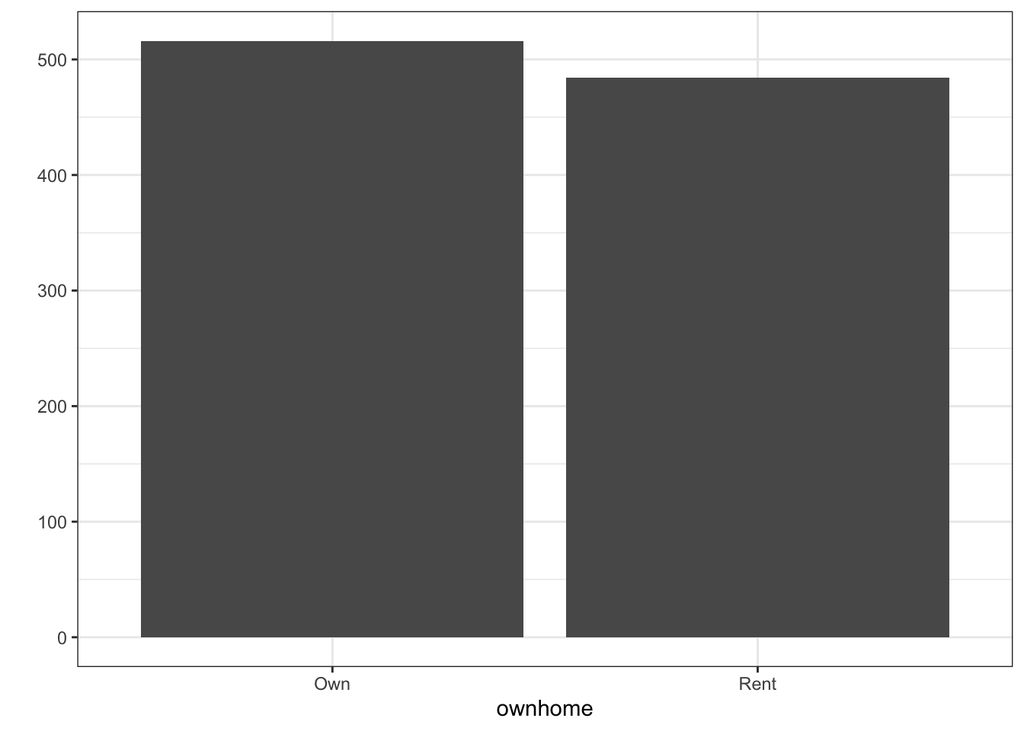

```r
qplot( data = dt.mktg
, x = ownhome
, geom = "bar") + theme_bw()
```

4. Married

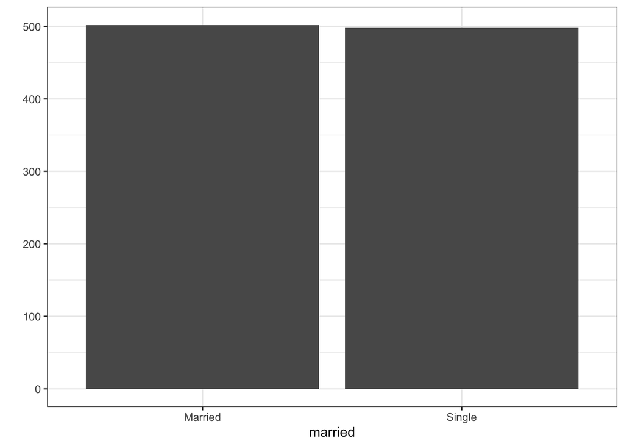

```r
qplot( data = dt.mktg
, x = married
, geom = "bar") + theme_bw()
```

5. Location

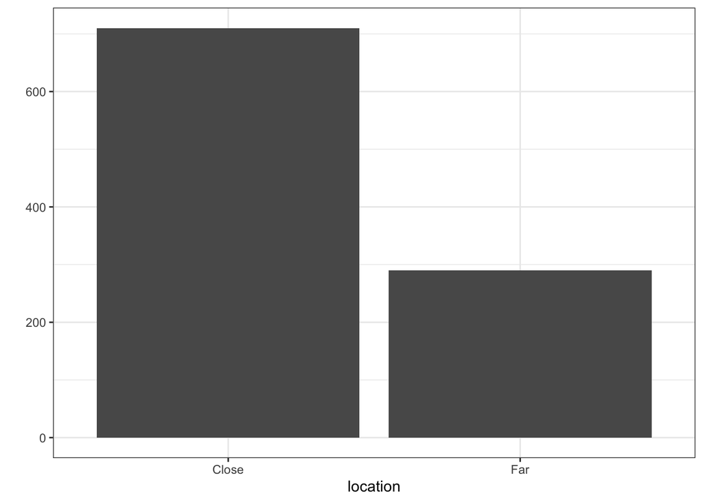

```r
qplot( data = dt.mktg
, x = location
, geom = "bar") + theme_bw()
```

6. Children

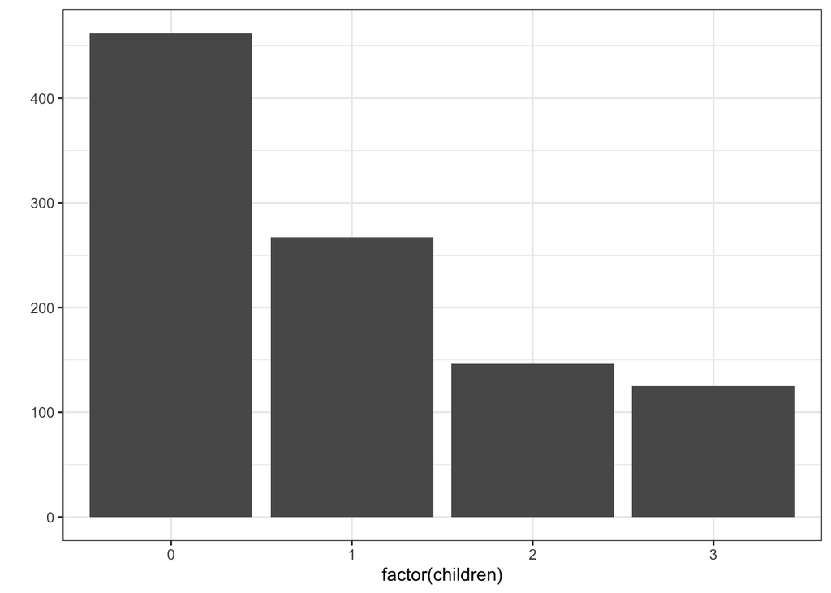

```r
qplot( data = dt.mktg
, x = factor(children)
, geom = "bar") + theme_bw()
```

7. History

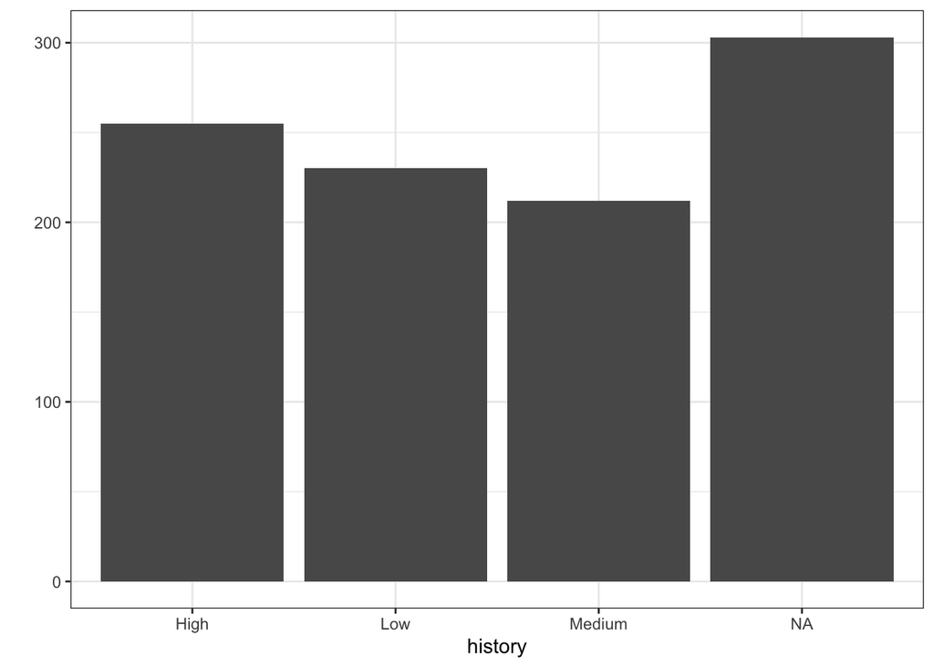

```r
qplot( data = dt.mktg
, x = history
, geom = "bar") + theme_bw()
```

8. Catalogs

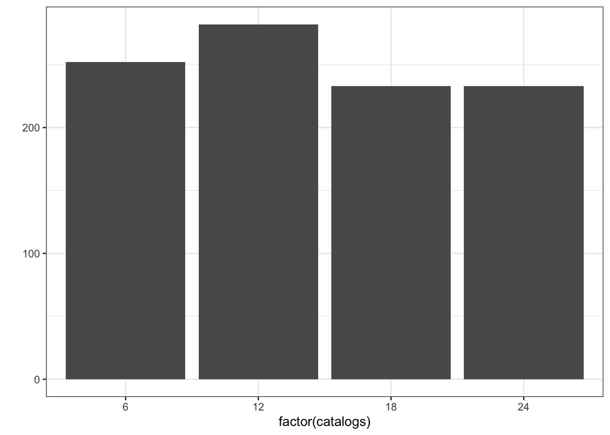

```r
qplot( data = dt.mktg
, x = factor(catalogs)
, geom = "bar") + theme_bw()
```

9. Salary 1

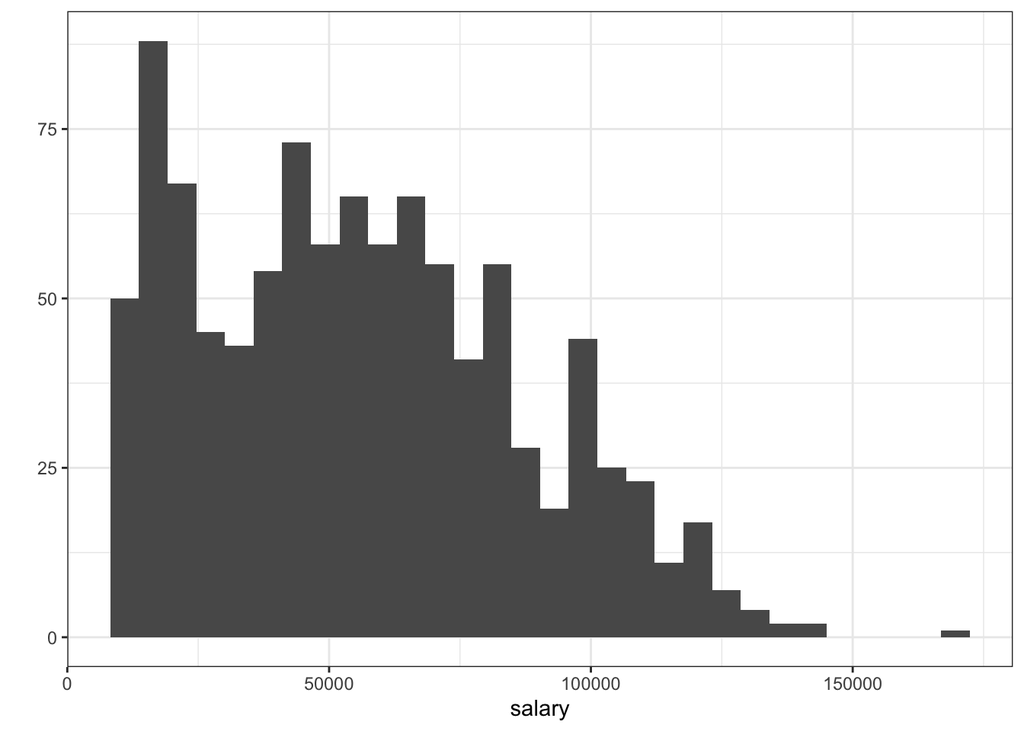

```r
qplot( data = dt.mktg
, x = salary
, geom = "histogram") + theme_bw()
```

10. Salary 2

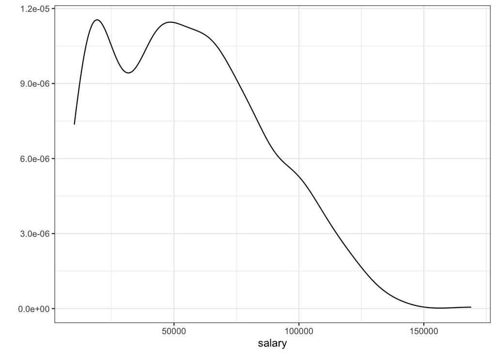

```r
qplot( data = dt.mktg
, x = salary
, geom = "density") + theme_bw()
```

11. Amount spent 1

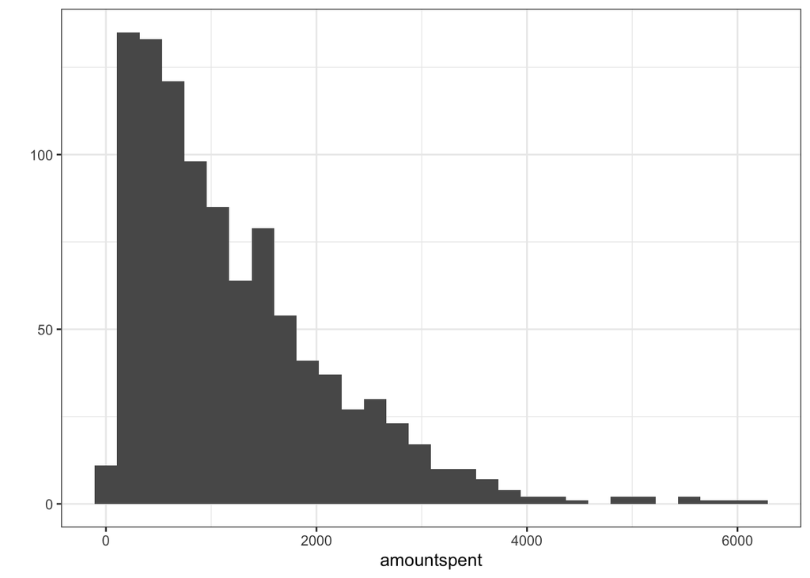

```r
qplot( data = dt.mktg
, x = amountspent
, geom = "histogram") + theme_bw()
```

12. Amount spent 2

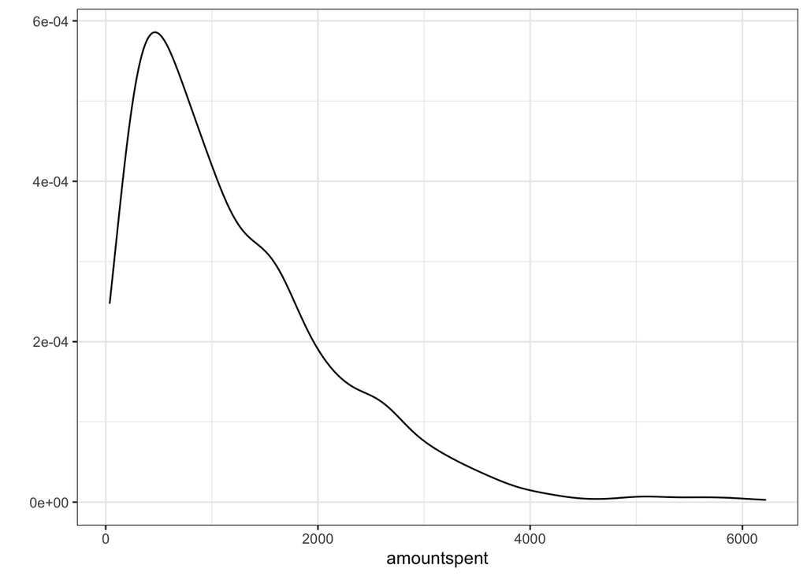

```r
qplot( data = dt.mktg
, x = amountspent
, geom = "density") + theme_bw()
```

13. Amount spent by age

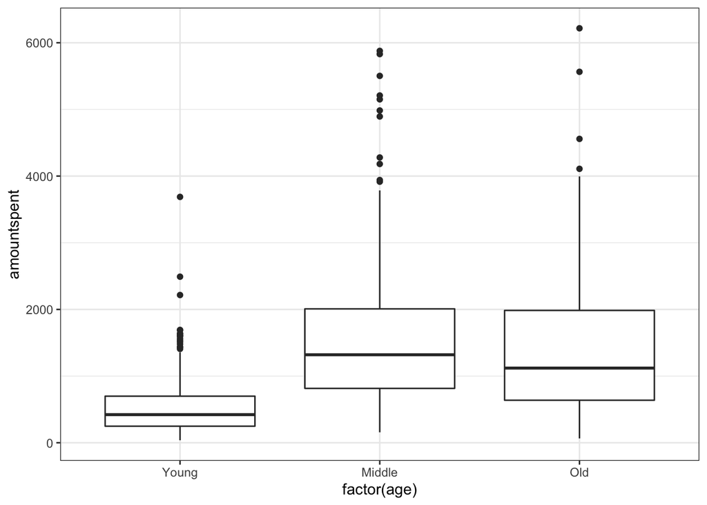

```r
qplot( data = dt.mktg
, x = factor(age)
, y = amountspent
, geom ="boxplot") + theme_bw() + xlim("Young","Middle","Old")
```

14. Amount spent by gender

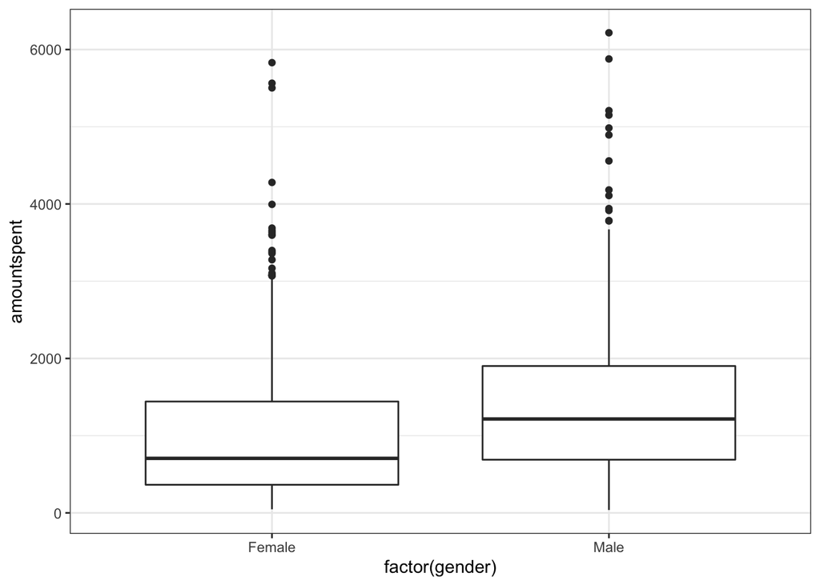

```r
qplot( data = dt.mktg
, x = factor(gender)
, y = amountspent
, geom ="boxplot") + theme_bw()
```

15. Amount spent if owing a home

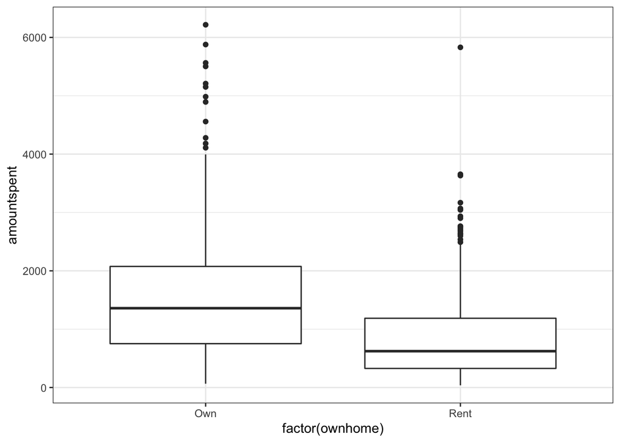

```r
qplot( data = dt.mktg
, x = factor(ownhome)
, y = amountspent
, geom ="boxplot") + theme_bw()
```

16. Amount spent if married

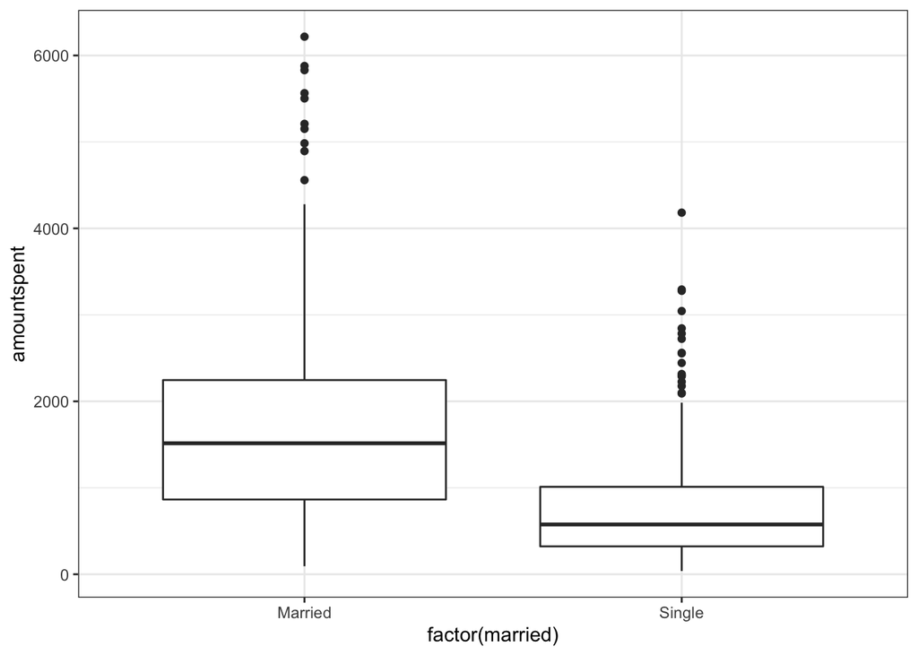

```r
qplot( data = dt.mktg
, x = factor(married)
, y = amountspent
, geom ="boxplot") + theme_bw()
```

17. Amount spent by location

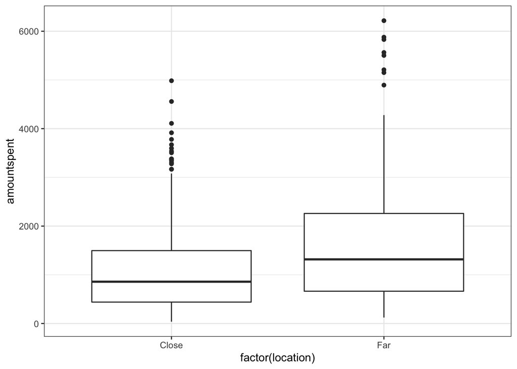

```r
qplot( data = dt.mktg
, x = factor(location)
, y = amountspent
, geom ="boxplot") + theme_bw()
```

18. Amount spent by N. of children

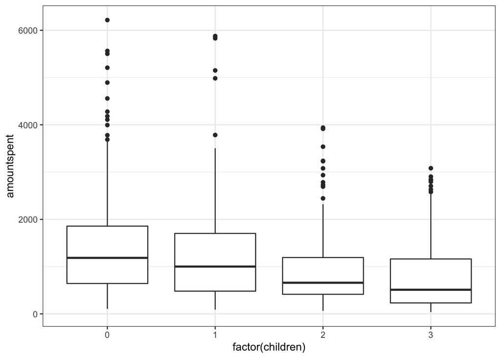

```r
qplot( data = dt.mktg
, x = factor(children)
, y = amountspent
, geom ="boxplot") + theme_bw()
```

19. Amount spent by history

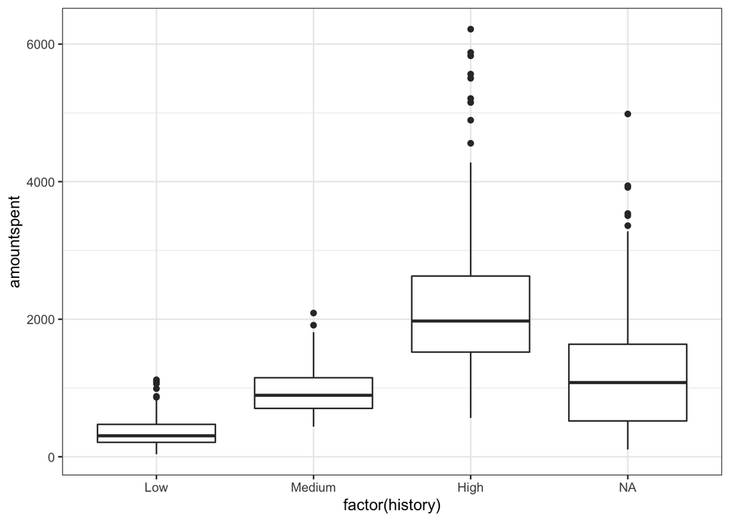

```r
qplot( data = dt.mktg
, x = factor(history)
, y = amountspent
, geom ="boxplot") + theme_bw() + xlim("Low", "Medium", "High", NA)
```

20. Amount spent by catalogs

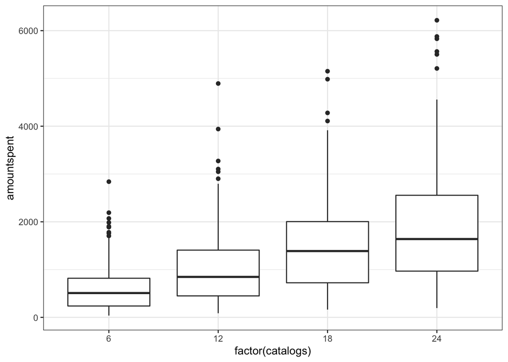

```r
qplot( data = dt.mktg
, x = factor(catalogs)
, y = amountspent
, geom ="boxplot") + theme_bw()
```

*Simple regression - Interpretation*

```r
lm1 <- lm(amountspent ~ salary, data = dt.mktg)
stargazer(lm1, type = "text")
```

```
##
## ===============================================
##                         Dependent variable:
##                     ---------------------------
##                             amountspent
## -----------------------------------------------
## salary                       0.022***
##                               (0.001)
##
## Constant                      -15.318
##                              (45.374)
##
## -----------------------------------------------
## Observations                   1,000
## R2                             0.489
## Adjusted R2                    0.489
## Residual Std. Error     687.065 (df = 998)
## F Statistic          956.694*** (df = 1; 998)
## ===============================================
## Note:               *p<0.1; **p<0.05; ***p<0.01
```

B0 = −15.318 and the corresponding standard error is 45.374. B0 is not significantly different from zero, thus the absence of stars by this coefficient. B1 = 0.022, and the corresponding standard error is 0.001. B1 is significant at the 1% level, indicated by the three stars by this coefficient. According to this simple regression model, for each unit (dollar) increase in the customer’s salary, we can expect an increase of 0.022 units (dollars) in the amount spent by the customer. The variable salary explains 49% of the variation in the variable amountspent (R2 = 0.489).

```r
lm2 <- lm(amountspent ~ location, data = dt.mktg)
stargazer(lm2, type = "text")
```

```
##
## ===============================================
##                         Dependent variable:
##                     ---------------------------
##                             amountspent
## -----------------------------------------------
## locationFar                 534.773***
##                              (64.837)
##
## Constant                   1,061.686***
##                              (34.916)
##
## -----------------------------------------------
## Observations                   1,000
## R2                             0.064
## Adjusted R2                    0.063
## Residual Std. Error     930.364 (df = 998)
## F Statistic           68.028*** (df = 1; 998)
## ===============================================
## Note:               *p<0.1; **p<0.05; ***p<0.01
```

B0 = 1,061.686 which is the average amount spent by customers who are “close” (where close is the omitted category of the variable location). In fact:

```r
dt.mktg[location=="Close", mean(amountspent)]
```

```
## [1] 1061.686
```

B1 = 534.7736. By adding B0 + B1 we get the average amount spent by customers who are “far”.

```r
dt.mktg[location=="Far", mean(amountspent)]
```

```
## [1] 1596.459
```

```r
lm3 <- lm(amountspent ~ history, data = dt.mktg)
stargazer(lm3 , type = "text")
```

```
##
## ===============================================
##                         Dependent variable:
##                     ---------------------------
##                             amountspent
## -----------------------------------------------
## historyLow                 -1,829.050***
##                              (56.917)
##
## historyMedium              -1,235.736***
##                              (58.174)
##
## Constant                   2,186.137***
##                              (39.196)
##
## -----------------------------------------------
## Observations                    697
## R2                             0.610
## Adjusted R2                    0.608
## Residual Std. Error     625.902 (df = 694)
## F Statistic          541.884*** (df = 2; 694)
## ===============================================
## Note:               *p<0.1; **p<0.05; ***p<0.01
```

B0 = 2,186.137 which is the average amount spent by customers who have a “high” purchase history (where “high” is the omitted category of the variable history). In fact:

```r
dt.mktg[history=="High", mean(amountspent)]
```

```
## [1] 2186.137
```

```r
stargazer(lm3 , type = "text")
```

```
##
## ===============================================
##                         Dependent variable:
##                     ---------------------------
##                             amountspent
## -----------------------------------------------
## historyLow                 -1,829.050***
##                              (56.917)
##
## historyMedium              -1,235.736***
##                              (58.174)
##
## Constant                   2,186.137***
##                              (39.196)
##
## -----------------------------------------------
## Observations                    697
## R2                             0.610
## Adjusted R2                    0.608
## Residual Std. Error     625.902 (df = 694)
## F Statistic          541.884*** (df = 2; 694)
## ===============================================
## Note:               *p<0.1; **p<0.05; ***p<0.01
```

B0 + B1 give us the average amount spent by customers who have a “low” purchase history:

```r
dt.mktg[history=="Low", mean(amountspent)]
```

```
## [1] 357.087
```

B0 + B2 give us the average amount spent by customers who have a “medium” purchase history:

```r
dt.mktg[history=="Medium", mean(amountspent)]
```

```
## [1] 950.4009
```

*Multiple regression*

```r
lm.spend1 <- lm( amountspent ~ gender + location + salary + children + catalogs
, data = dt.mktg)
stargazer(lm.spend1 , type = "text")
```

```
##
## ===============================================
##                         Dependent variable:
##                     ---------------------------
##                             amountspent
## -----------------------------------------------
## genderMale                    -42.309
##                              (33.959)
##
## locationFar                 508.129***
##                              (36.207)
##
## salary                       0.021***
##                               (0.001)
##
## children                    -205.806***
##                              (15.731)
##
## catalogs                     42.802***
##                               (2.544)
##
## Constant                    -528.143***
##                              (50.454)
##
## -----------------------------------------------
## Observations                   1,000
## R2                             0.715
## Adjusted R2                    0.714
## Residual Std. Error     514.103 (df = 994)
## F Statistic          499.438*** (df = 5; 994)
## ===============================================
## Note:               *p<0.1; **p<0.05; ***p<0.01
```

Alternatively, one shortcut for including all the variables in your dataset (except the dependent variable) as independent variables in your model is to use a “.”:

```r
lm.spend2 <- lm(amountspent ~ ., data = dt.mktg)
stargazer(lm.spend1, lm.spend2 , type = "text")
```

```
##
## ======================================================================
##                                    Dependent variable:
##                     --------------------------------------------------
##                                        amountspent
##                               (1)                       (2)
## ----------------------------------------------------------------------
## ageOld                                                41.385
##                                                      (52.764)
##
## ageYoung                                              89.654
##                                                      (58.741)
##
## genderMale                  -42.309                   -53.701
##                             (33.959)                 (38.016)
##
## ownhomeRent                                           -18.288
##                                                      (41.512)
##
## marriedSingle                                         19.503
##                                                      (49.812)
##
## locationFar                508.129***               608.992***
##                             (36.207)                 (43.985)
##
## salary                      0.021***                 0.019***
##                             (0.001)                   (0.001)
##
## children                  -205.806***               -268.283***
##                             (15.731)                 (25.019)
##
## historyLow                                          -267.514***
##                                                      (88.617)
##
## historyMedium                                       -344.553***
##                                                      (59.964)
##
## catalogs                   42.802***                 40.521***
##                             (2.544)                   (2.868)
##
## Constant                  -528.143***                -249.579*
##                             (50.454)                 (134.031)
##
## ----------------------------------------------------------------------
## Observations                 1,000                      697
## R2                           0.715                     0.789
## Adjusted R2                  0.714                     0.785
## Residual Std. Error    514.103 (df = 994)       463.457 (df = 685)
## F Statistic         499.438*** (df = 5; 994) 232.493*** (df = 11; 685)
## ======================================================================
## Note:                                      *p<0.1; **p<0.05; ***p<0.01
```

*Predict amount spent by new customer*

```r
new.client <- data.table( gender = "Male"
, location = "Close"
, salary = 53700
, children = 1
, catalogs = 12)
new.client
```

```
##    gender location salary children catalogs
## 1:   Male    Close  53700        1       12
```

```r
my.pred <- predict(lm.spend1, newdata = new.client)
my.pred
```

```
##        1
## 868.9695
```

```r
my.pred <- predict(lm.spend1, newdata = new.client, interval="prediction", level = .95)
my.pred
```

```
##        fit       lwr      upr
## 1 868.9695 -141.2554 1879.194
```